# Money Guard Cross Sell Modeling Project

Aiden V. Johnson

July 13, 2017

## Overview

#### Goal:

Identify current Life(NONMG) policy holders who are likely to buy a Moneyguard(MG) policy.

#### Data Sources:

KBM data, policy level data, Rx data(Excluded from Final Model) Filtered to Life and MG Products only  
Re-coded to MG and NONMG 485,372 policies

#### Data Timeframe:

1/1/2000-12/31/2015

#### Modeling Response:

Either MG or NONMG  
NONMG –> MG

#### Classification or Regression Model:

Classification

#### Deliverables:

Policy number list of NONMG policies with high probability of purchasing MG.

## Data Aggregation & Cleaning

#### Data Sources

Policy data was queried from ISL history table for all policies from 1/1/2000 to 12/31/2015. Data was culled based on product type; excluding all policy types except Moneyguard, IUL, VUL, TM, and GUL.

KBM data was queried for the cleaned policy list from ISL history,the kbm data is found in the INSIGHT_RPT database, the result included about 300 variables. These data were last updated in March 2016. These data include demographic, consumer behavior, and survey response datatypes. A detailed description of all the data in this model is provided in appendix A.

Rx data was queried for the cleaned policy list through Lifewriter(Winrisk). The RX data is counts of RX fills per person at the time of their initial underwriting for a life policy. Three categories exists; 1 is the least severe, 3 is the most severe. The date of the data depends on the effective date of the policy.

Policy State, and zip code were queried from the Name_table in Winrisk as well.

APS and Labs data presence and absence was initially included but later found to be problematic for the classification; as well as Underwriting ratings.

#### Data Cleaning

All the data collated together resulted in 330 variables to predict the policy class of either Moneyguard or Non-Moneyguard.Duplicate records were identified and deleted.

All variables that were considered id columns (100% unique) were excluded from the data to avoid prediction bias. Many of the variables contained NA or missing values; in this case we implemented a 50% rule and imputed the values. Those variables with more than 50% of the data missing were deleted. For the remaining Na’s in numeric data they were filled using the column median.For the factor and logical variables the Na’s were imputed based on the most common value in that variable. Variables with near zero variance were also removed from the data set to improve modeling efficiency.

## Exploratory Data Analysis

#### Dual policy holders

As part of the exploratory analysis policy holders that currently held both Life and MG policies were identified using the filtered data set and the DEDUPE_ID variable, which indicated more than one policy for that individual. Based on the dedupe id and the policy effective date we were able to identify individual who first purchased a Life policy and at a later date purchased a MG policy. There were 1100 of these dual policy holders who made the transition that we were interested in modeling in this effort. This groups attributes in terms of variable values provided a snapshot of what our target population may be. Although, the size of this group was markedly small compared to our 400,000 total data set. This subset transition class of observations was used as a comparative base line for further variable selection.

#### Variable Selection

Considering the numerous variables in the initial data set a traditional univariate or bivariate variable review would be inefficient. An initial model build was created to statistically identify the important predictors within our variables. This initial model was created using a random forest classification built and calibrated to provide a list of variable importance in modeling MG and NONMG policies. In addition, a random forest model was built using the transition class observations (those 1100 dual policyholders). The top 30 variables from both the MG and NONMG random forest model as well as the transition class model were compared. The Rx class count data was originally included in this top 30; however, after further review the Rx data was removed and the final model was refit excluding Rx data.

#### Univariate review of selected

A univariate review of these selected top 30 variables was completed. Each distribution was broken down by the MG and NonMG classes. The figure below is an example of those distribution plots.

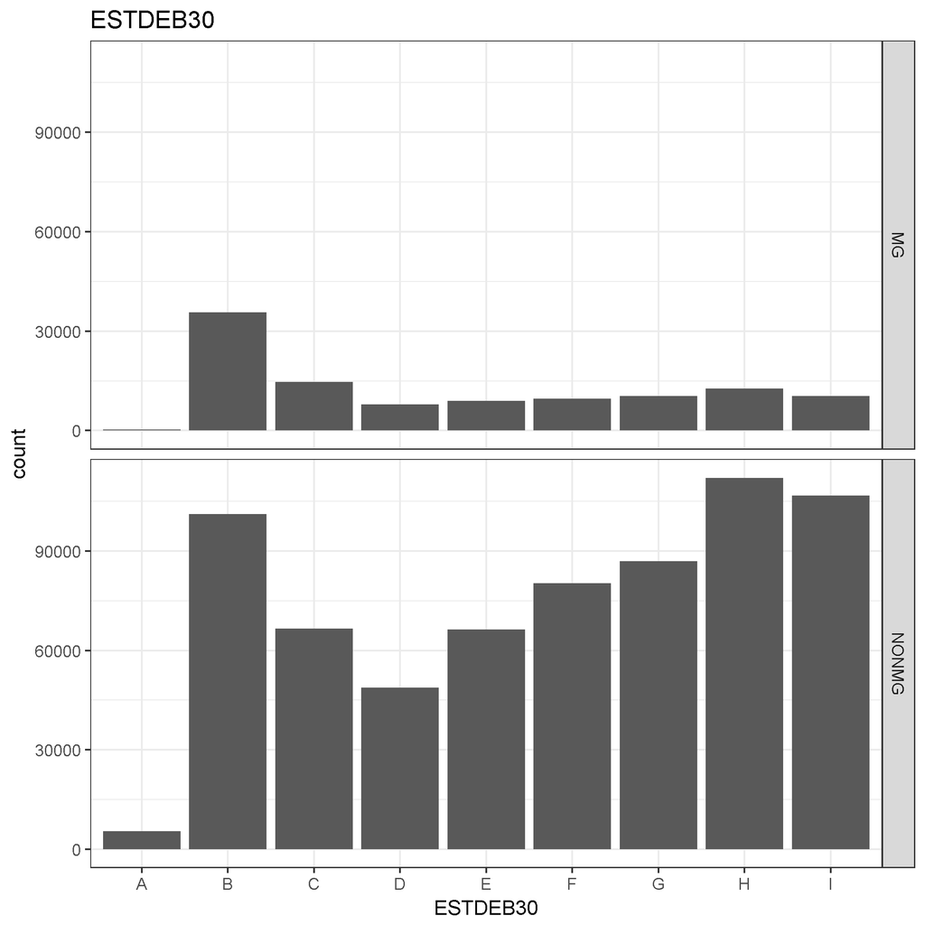

#### Variable Recoding

An initial step-wise logistic regression model illuminated the issue of high dimensional within the kbm categorical variables. Although, these variables were still strongly informing the model their high dimensions were limiting the overall number of variables that could be included as well as the assessment of the overall impact of the individual variables themselves.For example, age range variable included a category for each 5 year increment and it was determined through discussion that we could reduce all the five year increments under age 46 to one single category.The following variables were re-coded:

- Age Range
- Generation spending clusters
- Net worth
- Investable Assets
- Household composition
- Prepaid Funeral Offer
- Income
- Auto Insurance Offer

#### Composite variables

After remodeling with the re-coded variables there was still a need for additional model performance improvement. Distinct groupings within the distributions of the re-coded variables were identifies within the MG and NONMG classes. Based on these clear strong informers composite variables were created by re-coding the included variables to zero and one delineating the positive impact on classifying MG policies as one. Then the variables that logically combined well were summed to provide a composite variable with a range of impact values for MG policies. The following illustration explains the process.

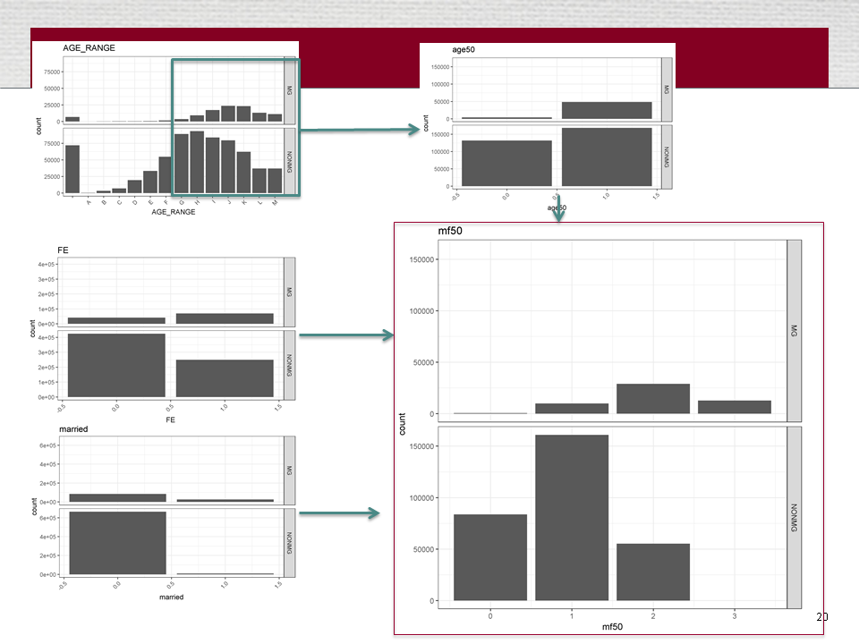

#### List of Composite Variables:

- Married + 50 yo + female
- Married + 50 yo +debt class
- Married + 50 yo + debt class+ investable assets
- Married + 50 yo + income
- Married + 50 yo + investable assets
- Rx Rating 1 +Tobacco Rating
- Rx Rating 2 + Tobacco Rating
- Rx Rating 3 + Tobacco Rating
- State + Rating
- Zip + Rating

#### Variable List Re-expanded

With expanded model convergence space created by the re-coding of variables, additional previously excluded variables were added back in to the modeling process. Instead of only including the top 15 variables we compared the top 30 variables in the original MG and NONMG model with the top 30 variables in the transition class model. A total of 19 variables were found in both models, so those overlap variables were included. Additionally, the ratings classes, Rx data, the composite variables and ZIP code, state, Census Statistical Area were included in the next modeling phase.

#### Principle Component Analysis

In continued pursuit of data dimension reduction a PCA was calculated based on the above data.A PCA is an orthogonal data transformation with components equal to the number of data dimensions.Each component was a relatively small portion of the variance.

#### Final Variable list

##### 1. KBM Variables

- GENERS
- ESTDEB30
- INSPAFUN
- ESTINC30
- FAMP
- HHCOMP
- NETW30
- ESTINV30
- IRIAUTO
- LTCINDX
- SSPIDENT
- INSFINEX
- DESTGRP
- MEDSUP
- CHANPR1

##### 2. Policy Level data

- Zip
- State
- Married

##### 3. Composite Variables

- m50inc
- m50inv
- m50debt
- mf50
- age50

## Model Testing

#### Types of models: Logistic Regression, Random Forest, Tree Models

The first model comparison build was a Logistic regression model compared to a random forest model. The step wise logistic regression routine landed on the following model formation:

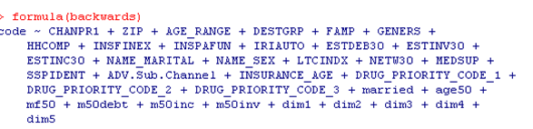

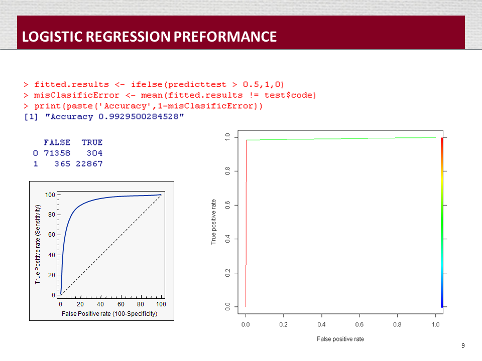

The Random Forest model based on the same set of variables appeared to perform well. Performance indicators below:

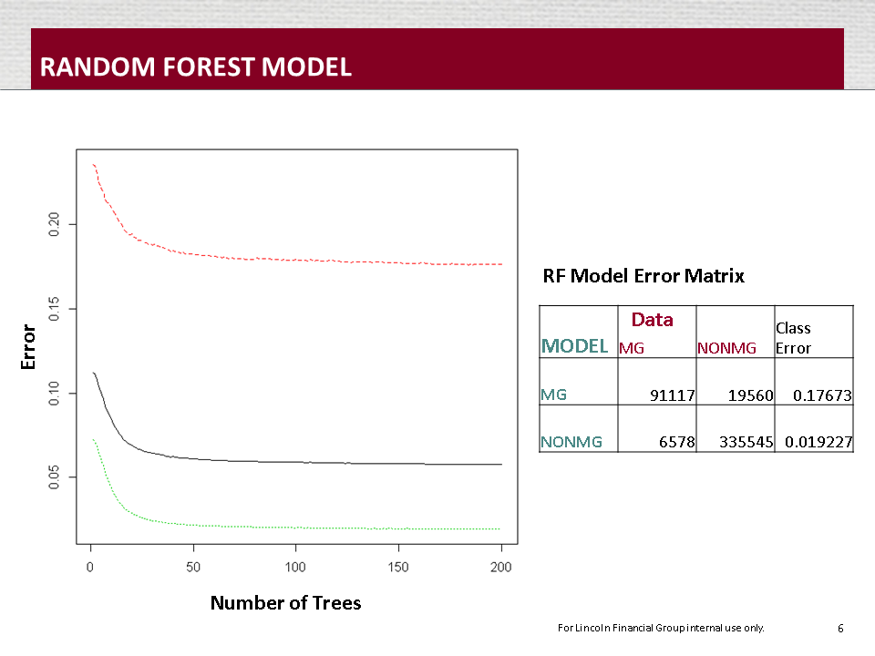

#### Model Development

After model performance demonstrated the over fitting with PCA, those components were excluded from the next iteration of model building. The random forest model performed well even with the exclusion of the PCA variables. This model provided classification results, e.g. the predicted output was a class of either MG or NONMG.

In order to support scoring of policies for ranking in terms of confidence in those predictions a tree model was implemented which returned a probability score of being a MG. This tree model is functionally similar to random forest yet much more efficient and not quite as robust. This allowed for a ranking of confidence in the random forest model predictions. The tree model has to be tuned with a complexity error evaluation and then re-run to reach an appropriate model for predictions.The tree model was built with the same input variables.

In an additional step of performance evaluation we created a class prediction based on the tree predictions greater than 0.5. Evaluating the overlap in class predictions between the random forest and tree model indicted about 60% overlap. This is slightly lower than preferred; however, it is in line with level of variation and disproportionate number of MG to NONMG observations.

A set of random forest model predictions as well as tree model predictions were generated as the policies to implement in the cross sell program. After discussions with compliance it was determined to remove the RX data from the final model. The impact of removing the RX data from the final model results in an overall accuracy reduction of 2% for the random forest model.

#### Random Forest Model with RX data

| Model | MG | NONMG | Total | Pos.Pred |
| --- | --- | --- | --- | --- |
| MG | 10524 | 560 | 11084 | 0.95 |
| NONMG | 5465 | 28731 | 34196 | NEG.Pred |
| Total | 15989 | 29291 | 45280 | 0.84 |
| Actual | 0.66 | 0.84 | - | - |
| - | Sensitivity | Specificity | Total.Accuracy | 0.87 |

#### Random Forest Model without RX data same seed set

| Model | MG | NONMG | Total | Pos.Pred |
| --- | --- | --- | --- | --- |
| MG | 10496 | 681 | 11177 | 0.94 |
| NONMG | 6174 | 27929 | 34103 | NEG.Pred |
| Total | 16670 | 28610 | 45280 | 0.82 |
| Actual | 0.63 | 0.82 | - | - |
| - | Sensitivity | Specificity | Total.Accuracy | 0.85 |

## Final Model

The final model is an iteration of random forest and a tree model with the seed set at 1234. The random forest model is a classification with a min split size of 1 and 50 trees; tuning of these parameters was completed through an iterative search of parameter optimization. The 10% data hold out confusion matrix is above:

The final variable importance and variable usage is here:

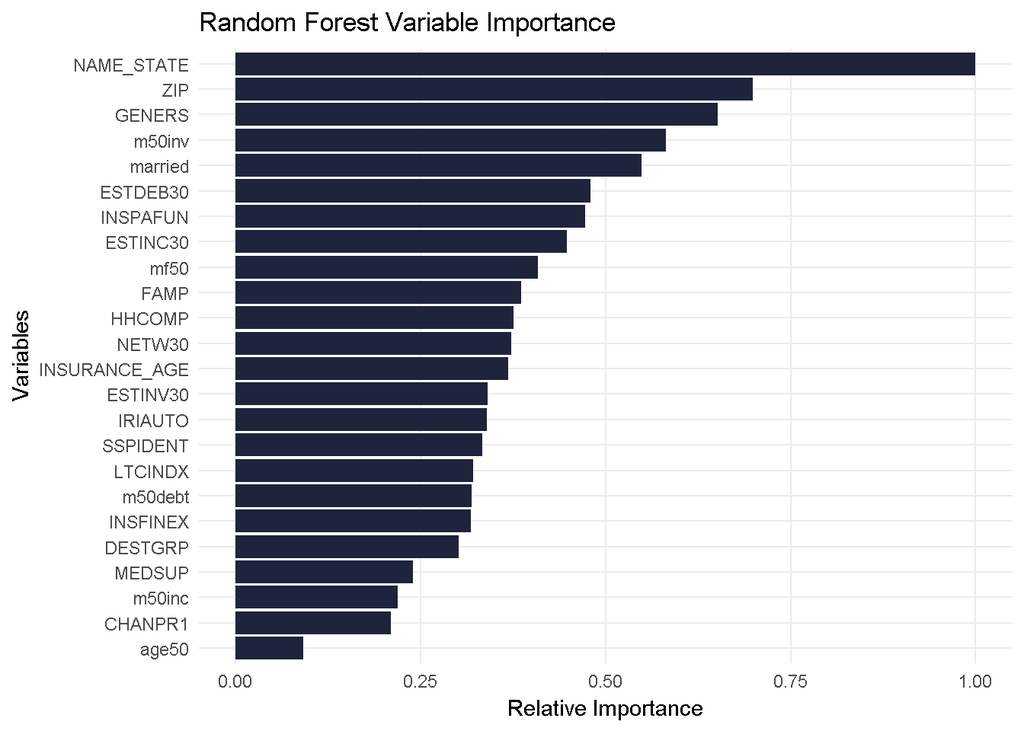

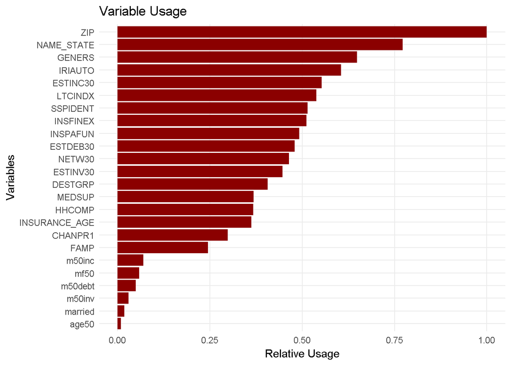

This model resulted in 60,999 NONMG policies classed as MG.This is a large number and indicates the need for a scoring approach provided by the more simplified tree model.The complexity parameter is optimized in the first iteration of the tree model and then cp is set to that optimum level for the number of trees to grow in the next iteration. A visualization of the impact of cp on relative error is provided here:

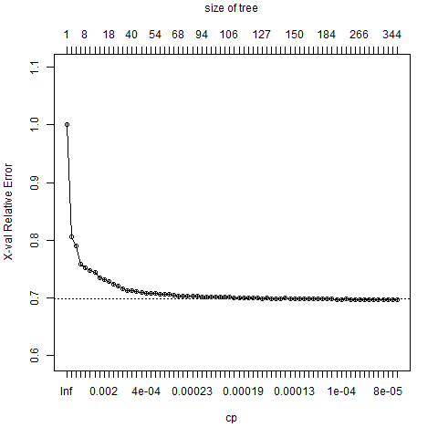

The tree model performed well also. In addition the overlap of the tree and random forest model predictions was evaluated.

[output not shown]

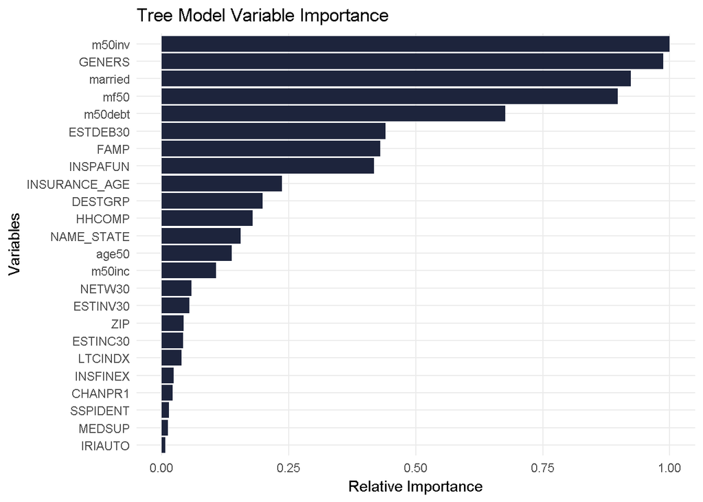

Each model was fit with and without the RX data. The policy counts for each and within the overlap for both models is provided here:

#### Final Model Comparisons

| RF.RX | Tree.RX | RF.NoRX | Tree.NoRX | Both.RF | Both.Tree |
| --- | --- | --- | --- | --- | --- |
| 55538 | 17769 | 60999 | 16809 | 38219 | 11091 |

## Appendix A: Long Data Description

Currently we have 3 data sources and 4 data types.

### 1. KBM data

Survey data obtained from Customer Insights of about 300 variables. These data were used in the App Triage model as well. Generally model predicted indicators of lifestyle behaviors such e.g. spending habits, household structure, and economic indicators.

#### A subset of 15 out of the 300 variables has been identified to be included in the final model.

#### GENERS

A segmentation system comprised of five generational groups and 52 unique clusters based on common purchasing power and behavior, lifestyle choices, demographic attributes, socioeconomic status and attitudes.

| Code | Title | Definition | Count | Percent |
| --- | --- | --- | --- | --- |
| 0 | Uncoded | This record is uncoded | 19614 | 0.04 |
| 1 | Strapped Seniors | Small blue-collar households, making due with less, often in mobile homes in the Midwest and South. Not credit active, they respond to fishing, country and Christian music, and bible study - but not t… | 3120 | 0.01 |
| 2 | Rich Retirees | Well-educated and well-off, enjoying everything Northeastern big cities have to offer. Small households, big net worth. With interests ranging from theater to cooking, they’re too busy to surf the int… | 6912 | 0.02 |
| 3 | Blooming in the Burbs | Although mostly empty nesters, these ‘burb-loving’ Seniors live in family-oriented neighborhoods. Pure Middle America, but with a Hispanic flair in the West and Central regions. They enjoy average to … | 10428 | 0.02 |
| 4 | Retired Renters | Low-income Seniors, living mostly in apartments and condos in large Northeastern urban centers. Ethnically diverse and often living alone, they are neither digitally inclined, nor into mail order purc… | 5838 | 0.01 |
| 5 | Minorities in the Majority | Minorities who relish the diversity of city life throughout the SE, NE and Midwest, despite shrinking incomes. They have struggled through tough times and are often divorced. Not into the internet or … | 1177 | 0.00 |
| 6 | Indulgent Intellectuals | In debt and credit-happy, these small household homeowners in the central and Midwest prefer tonier pursuits: from reading to environmental advocacy. They use email, respond to mail order and dote on … | 12407 | 0.03 |
| 7 | Family Friendly | Lower-income Seniors, living in large households in smaller communities - often with their children. Hers: doll collecting, quilting and sewing. His: camping, hunting and fishing. They have online acc… | 2119 | 0.00 |
| 8 | Retirement Retreats | These moderate-income Seniors live among other Seniors just like them, in suburban neighborhoods outside major Eastern cities. Unlikely to own a home, their smaller households are not particularly cre… | 2439 | 0.01 |
| 9 | Urban Upper Crust | Well-to-do, urban, married shopaholics, who love their credit cards. Into fitness and health, travel, gardening and golf. They use email and shop online and by mail. With the highest net worth, they c… | 16733 | 0.04 |
| 10 | Boomerang Bohemians | Free-wheeling RVers, digitally connected and financially secure. Many still work and travel frequently. Although still homeowners, they often call their kid’s house home. Email users and online and ma… | 8542 | 0.02 |
| 11 | Small Town Traditionalist | Traditional and conservative; likely work in a blue collar job; struggling with the impact of loss of jobs and out-migration. Limited online access and don’t purchase by mail. Low income, lowest home … | 645 | 0.00 |
| 12 | Gold’n’Gray | Exclusive suburbs, luxury travel, retirement nest eggs, portfolio management; mostly execs and upper-level professionals; many still working part-time or consulting. Highest income, newer homes, mostl… | 8092 | 0.02 |
| 13 | Small Town Singles | Low average household size and income. Mostly blue collar towns and neighborhoods; not online, they live on their own in small cities or towns. | 1574 | 0.00 |
| 14 | Mainstream Matures | Typical Boomers, not particularly religious or political; professional jobs, comfortably middle class. Online, active mail order buyers. | 9608 | 0.02 |
| 15 | American Bedrock | Traditional and stable; grandparents; community and church oriented; modest income, but live comfortably. Lots of mail order (not email), large households, with 20-something children. | 5573 | 0.01 |
| 16 | Urban Mix | Multi-ethnic, apartment dwellers, single professionals with higher than average education. Gentrified, trendy and mixed urban neighborhoods. | 3999 | 0.01 |
| 17 | Urban Blues | Ethnically very mixed; very vulnerable in both health and finances. Living in central city apartments, public transportation dependent, their neighborhoods and lives are both transitional; they have t… | 1121 | 0.00 |
| 18 | Credit Commandos | Slightly above average income, heavy credit users. Confirmed suburbanites and empty nesters, they’re making up for lost time by buying on time. | 27425 | 0.06 |
| 19 | Blue Collar Strugglers | Predominantly African American, living in the older blue collar neighborhoods of urban areas. They are making ends meet but don’t have much extra. | 867 | 0.00 |
| 20 | Settled Suburbanites | With income and home value both higher than average, these empty nesters are happy to stay right where they are, they have the longest average length of residency of any segment. Heavy mail order buye… | 24475 | 0.05 |
| 21 | Classic Rockers | Boomers raised on Rock & Roll, now living in the `burbs’ and raising teens; ready to buy by mail and online. | 29094 | 0.06 |
| 22 | All-American Online | Net-savvy Boomers and their Boomerang offspring. They have the largest household size and are ready to meet their many needs and wants online. | 13954 | 0.03 |
| 23 | Rural Outsiders | Rural, low income - highest percent in mobile homes, highest percent white. Country isn’t just where they live it’s who they are. Strong traditionalists, they tend to be isolated with no internet acce… | 299 | 0.00 |
| 24 | Family Transitionals | Living in typical, middle class suburbs, sharing their space with 20-something children, they are still transitioning toward empty nesting and retirements. | 45171 | 0.10 |
| 25 | Urban Outsiders | Single in the city, making their way in very transitional neighborhoods with low home ownership, high-percentage of recent move-ins. Tend to be isolated, with no Internet access. | 1050 | 0.00 |
| 26 | Suburban Mainstream | The American Dream, suburban style. Minivans whizzing from work to school events to soccer practice set the hectic pace. | 6686 | 0.01 |
| 27 | Metro Influentials | Stocks & investments, luxury travel & vehicles, fine wine, and gourmet food. Have the means and savvy to live out their dreams. Highest income, house value and home ownership. | 9042 | 0.02 |
| 28 | Wired Wanderers | Distinguishing characteristic is presence online, short average length of residence. Online is where they live. | 842 | 0.00 |
| 29 | Urban Sophisticates | Citified apartment dwellers; think gentrified neighborhoods, coffee houses and lofts. Ethnically diverse, politically liberal, these well-educated professionals, have above average income - but are no… | 2956 | 0.01 |
| 30 | Suburban Strivers | They want it all, but what they really have is credit. And they use it. Their address is in the suburbs, but could be living beyond their means. | 16507 | 0.04 |
| 31 | Empty Nest Caregivers | The kids are grown and gone, but Mom or Dad have moved in. Likely caregivers, the demands on their time make them heavy mail order buyers. | 3606 | 0.01 |
| 32 | American Family Up-and-Coming | From SUVs and computers, home improvements to HDTV, they’re movin’ on up. Plugged in, savvy consumers, purchasing frequently both online and by mail. | 21957 | 0.05 |
| 33 | Blue Collar Blend | With small households and a shorter average length of residence, they’re an ethnically mixed group in transition. Working for a paycheck in blue collar neighborhoods, they’re not online, don’t buy by … | 259 | 0.00 |
| 34 | Urban Strugglers | It’s not always pretty in the city. They’re hanging on in the oldest homes, getting by instead of getting ahead. Mostly African American; many are single, but they still live in single family, working… | 671 | 0.00 |
| 35 | Large Extended Families | While an elderly parent in the home strains the family budget of these knowledge-hungry homeowners, they still manage to pursue their many interests. They are family-oriented information junkies and a… | 14087 | 0.03 |
| 36 | Urban Singles | These upwardly mobile singles earn competitive incomes and have no one to spend them on but themselves. With no children or mortgage to worry about, they are free to enjoy all that city life has to of… | 3881 | 0.01 |
| 37 | Established & Settling In | As they ease toward their 40s, these consumers enjoy competition and winning, and their high income levels prove they have succeeded professionally. They have moved on from apartment living, are doing… | 30795 | 0.07 |
| 38 | Rural & Barely Making It | Comprising about one-fourth of all Gen Xers, these rural individuals make the most of their modest income with do-it-yourself home improvements. They cherish their homes, even though their home values… | 6647 | 0.01 |
| 39 | Married with Children | The typical American family - updated: These active, married people are raising children and surfing the Web. Predominantly homeowners, they visit a broad range of sites and make online purchases from… | 3392 | 0.01 |
| 40 | Struggling in Suburbia | Suburbia isn’t all it’s cracked up to be for these individuals. Few hold a college degree, and even fewer have investments. With some of the lowest household incomes among their peers and low househol… | 2061 | 0.00 |
| 41 | Ethnically Diverse Urbanites | These minorities are barely squeaking by in the big cities of Illinois, Maryland, New York and Washington, D.C. With little household income, they can’t afford to buy a house. These individuals have l… | 1232 | 0.00 |
| 42 | Moving on a Steady Course | These multitaskers are busy fulfilling daily obligations while also planning for the future. These folks are both parents and investors who enjoy cooking, gardening, sewing and exercising. They seek c… | 8957 | 0.02 |
| 43 | Big Bucks in the Big Cities | Living in the big city costs lots of money, and these college-educated men and women have plenty of it. With the highest household income among their peers, these family-focused individuals have the m… | 15176 | 0.03 |
| 44 | Ethnic Second-City Strugglers | About one-fifth of Millennials are financially struggling to make it in midsize cities. With lower income and household net worth than their peers, these minorities don’t have the means to buy a home … | 1923 | 0.00 |
| 45 | Young. Single & Mobile | These healthy, competitive trailblazers have few ties beyond their personal interests. They move often and have no investments. The youngest Millennials, these consumers are adventurous and enjoy tryi… | 1815 | 0.00 |
| 46 | Setting Up House & Settling Down | These Millennials are established in their careers and approaching their 30s. They have higher than average income and net worth. Eight out of 10 own homes, but since few have spouses or children, the… | 4135 | 0.01 |
| 47 | Start-Ups in the Country | Though these country Millennials are oldest among their peers, their lives are just getting started. These rural, single people do not have children, and only one out of five is a homeowner. They are … | 1506 | 0.00 |
| 48 | Parents on the Go | Although these moms and dads are focused on caring for their families, they still seek control. They enjoy cooking but, with little time, opt for takeout. No time to find specialty stores means one-st… | 18008 | 0.04 |
| 49 | Living Off Mom & Dad | This inquisitive, creative group is not in a rush to get out on their own. Although they are approaching 30, they are still content living with Mom and Dad. These Millennials embrace life and its oppo… | 5887 | 0.01 |
| 50 | Chronic Responders | These mail-order addicts love the outdoors, do-it-yourself projects, gardening and cooking. Although these young parents have average income and cope with many chronic medical issues, they are still s… | 2464 | 0.01 |
| 51 | Young Single in the City | These college-educated up-and-comers are finding success in the city. Still in their late 20s, these Millennials have the highest incomes per person and the highest median home values within Generatio… | 4689 | 0.01 |
| 52 | Family First | Still in their mid-20s, these Millennials aren’t quite ready to strike out on their own. These intellectuals live in their parents’ homes, along with other extended family members. With moderate incom… | 1343 | 0.00 |

#### ESTINC30

A demographic based analytically model which predicts the household income.

| Code | Description | Count | Percent |
| --- | --- | --- | --- |
| A | LESS THAN $15,000 | 5141 | 0.01 |
| B | $15,000-$19,999 | 2780 | 0.01 |
| C | $20,000-$29,999 | 6860 | 0.02 |
| D | $30,000-$39,999 | 8952 | 0.02 |
| E | $40,000-$49,999 | 11383 | 0.03 |
| F | $50,000-$59,999 | 15311 | 0.03 |
| G | $60,000-$74,999 | 28895 | 0.06 |
| H | $75,000-$99,999 | 57799 | 0.13 |
| I | $100,000-$124,999 | 54124 | 0.12 |
| J | $125,000-$149,999 | 42320 | 0.09 |
| K | $150,000-$199,999 | 64274 | 0.14 |
| L | $200,000-$249,999 | 50154 | 0.11 |
| M | $250,000-$399,999 | 47411 | 0.10 |
| N | $400,000-$499,999 | 10725 | 0.02 |
| O | $500,000+ | 46671 | 0.10 |

#### IRIAUTO

A statistical model predicting an individual’s likelihood of responding to automotive insurance offers. Includes both offline and online respondents.

| Code | Description | Count | Percent |
| --- | --- | --- | --- |
| 0 | MOST LIKELY | 28509 | 0.06 |
| 1 |  | 27089 | 0.06 |
| 2 |  | 29953 | 0.07 |
| 3 |  | 35386 | 0.08 |
| 4 |  | 42770 | 0.09 |
| 5 |  | 47971 | 0.11 |
| 6 |  | 56217 | 0.12 |
| 7 |  | 62687 | 0.14 |
| 8 |  | 66069 | 0.15 |
| 9 | LEAST LIKELY | 56149 | 0.12 |

#### LTCINDX

Indicates the propensity of an individual age 45+ to respond to a long term care insurance offer. The value of 0 indicates individual is most likely to respond and 9 being the least likely to respond.

| Code | Description | Count | Percent |
| --- | --- | --- | --- |
| 0 | MOST LIKELY | 89327 | 0.20 |
| 1 |  | 62716 | 0.14 |
| 2 |  | 143627 | 0.32 |
| 3 |  | 42472 | 0.09 |
| 4 |  | 36801 | 0.08 |
| 5 |  | 23594 | 0.05 |
| 6 |  | 21189 | 0.05 |
| 7 |  | 16394 | 0.04 |
| 8 |  | 9285 | 0.02 |
| 9 | LEAST LIKELY | 7395 | 0.02 |

#### SSPIDENT

A statistical model predicting an individual likely to respond to dental insurance offers.

| Code | Description | Count | Percent |
| --- | --- | --- | --- |
| 0 | MOST LIKELY | 131786 | 0.29 |
| 1 |  | 86540 | 0.19 |
| 2 |  | 44701 | 0.10 |
| 3 |  | 44185 | 0.10 |
| 4 |  | 31817 | 0.07 |
| 5 |  | 34249 | 0.08 |
| 6 |  | 25086 | 0.06 |
| 7 |  | 21891 | 0.05 |
| 8 |  | 20071 | 0.04 |
| 9 | LEAST LIKELY | 12474 | 0.03 |

#### INSFINEX

A demographic based analytical model which predicts the likelihood the household may respond to a marketing offer for final expense insurance.

| Code | Description | Count | Percent |
| --- | --- | --- | --- |
| 0 | MOST LIKELY | 19923 | 0.04 |
| 1 |  | 24440 | 0.05 |
| 2 |  | 28344 | 0.06 |
| 3 |  | 33580 | 0.07 |
| 4 |  | 33669 | 0.07 |
| 5 |  | 33829 | 0.07 |
| 6 |  | 32307 | 0.07 |
| 7 |  | 25420 | 0.06 |
| 8 |  | 20585 | 0.05 |
| 9 | LEAST LIKELY | 200703 | 0.44 |

#### INSPAFUN

A demographic based analytical model which predicts the likelihood the household may respond to an offer of prearranged/prepaid funeral planning.

| Code | Description | Count | Percent |
| --- | --- | --- | --- |
| 0 | MOST LIKELY | 68357 | 0.15 |
| 1 |  | 71747 | 0.16 |
| 2 |  | 65526 | 0.14 |
| 3 |  | 47224 | 0.10 |
| 4 |  | 23312 | 0.05 |
| 5 |  | 45124 | 0.10 |
| 6 |  | 25775 | 0.06 |
| 7 |  | 30711 | 0.07 |
| 8 |  | 20846 | 0.05 |
| 9 | LEAST LIKELY | 54178 | 0.12 |

#### ESTDEB30

A demographic based analytical model which predicts the household annual level of financial debt.

| Code | Description | Count | Percent |
| --- | --- | --- | --- |
| A | $0.00 | 3424 | 0.01 |
| B | $1 - $1,499 | 86983 | 0.19 |
| C | $1,500 - $3,499 | 48640 | 0.11 |
| D | $3,500 - $7,499 | 32882 | 0.07 |
| E | $7,500 - $14,999 | 42661 | 0.09 |
| F | $15,000 - $24,999 | 50091 | 0.11 |
| G | $25,000 - $39,999 | 54288 | 0.12 |
| H | $40,000 - $74,999 | 69362 | 0.15 |
| I | $75,000+ | 64469 | 0.14 |

#### NETW30

A demographic based analytical model which predicts the household net worth. Net worth is calculated by households total assets (deposit accounts, investments and home value) minus liabilities (loans, mortgages and credit card debt).

| Code | Description | Count | Percent |
| --- | --- | --- | --- |
| A | $0 OR LESS | 17290 | 0.04 |
| B | $1 - $4,999 | 4292 | 0.01 |
| C | $5,000 - $24,999 | 9159 | 0.02 |
| D | $25,000 - $49,999 | 10984 | 0.02 |
| E | $50,000 - $74,999 | 10766 | 0.02 |
| F | $75,000 - $99,999 | 11563 | 0.03 |
| G | $100,000 - $149,999 | 21506 | 0.05 |
| H | $150,000 - $249,999 | 38379 | 0.08 |
| I | $250,000 - $374,999 | 42151 | 0.09 |
| J | $375,000 - $499,999 | 34894 | 0.08 |
| K | $500,000 - $749,999 | 59001 | 0.13 |
| L | $750,000 - $999,999 | 61365 | 0.14 |
| M | $1,000,000 + | 131450 | 0.29 |

#### ESTINV30

A demographic based analytical model which predicts the household annual amount of invest able assets.

| Code | Description | Count | Percent |
| --- | --- | --- | --- |
| A | LESS THAN $5,000 | 32844 | 0.07 |
| B | $5,000-$24,999 | 16586 | 0.04 |
| C | $25,000-$49,999 | 20006 | 0.04 |
| D | $50,000-$74,999 | 17736 | 0.04 |
| E | $75,000-$99,999 | 14829 | 0.03 |
| F | $100,000-$249.999 | 74251 | 0.16 |
| G | $250,000-$499,999 | 84795 | 0.19 |
| H | $500,000-$749,999 | 61934 | 0.14 |
| I | $750,000-$999,999 | 36511 | 0.08 |
| J | $1,000,000+ | 93308 | 0.21 |

#### DESTGRP

Organizes the 45 Digital Destinations to provide a higher level view of an individuals online destinations and behaviors.

| Code | Description | Count | Percent |
| --- | --- | --- | --- |
| 1 | Low Cost Social Networking | 3334 | 0.01 |
| 2 | Career Oriented Online Shoppers | 23712 | 0.05 |
| 3 | Social Extremes | 5249 | 0.01 |
| 4 | Teen at the Stick | 2374 | 0.01 |
| 5 | Well Read Executives | 66693 | 0.15 |
| 6 | Online in the Hearth Room | 49324 | 0.11 |
| 7 | Middle-Aged with Hobbies | 9366 | 0.02 |
| 8 | Social Network Games & Shopping | 12233 | 0.03 |
| 9 | Multi-Dimensional Youngsters | 3155 | 0.01 |
| 10 | We Dont Shop Online | 16208 | 0.04 |
| 11 | Shopping Seniors | 27493 | 0.06 |
| 12 | Retiring Rich Online | 59792 | 0.13 |
| 13 | White Collar Commerce | 19501 | 0.04 |
| 14 | Enjoying Retirement | 131460 | 0.29 |
| 15 | At Home in Jammies | 22425 | 0.05 |
| 99 | Unknown | 481 | 0.00 |

#### MEDSUP

Indicates the propensity of and individual aged 65 or older to respond to a Medicare Supplement

| Code | Description | Count | Percent |
| --- | --- | --- | --- |
| 0 | MOST LIKELY TO RESPOND | 5598 | 0.01 |
| 1 |  | 7888 | 0.02 |
| 2 |  | 9276 | 0.02 |
| 3 |  | 10265 | 0.02 |
| 4 |  | 10561 | 0.02 |
| 5 |  | 11571 | 0.03 |
| 6 |  | 333283 | 0.74 |
| 7 |  | 16750 | 0.04 |
| 8 |  | 21208 | 0.05 |
| 9 | LEAST LIKELY TO RESPOND | 26400 | 0.06 |

#### HHCOMP

Indicator of the household composition based on family position and presence of children.

| Code | Description | Count | Percent |
| --- | --- | --- | --- |
| A | MARRIED WITH CHILDREN | 134269 | 0.30 |
| B | MARRIED WITH NO CHILDREN | 132296 | 0.29 |
| C | 2 PERSONS - ONE MALE, ONE FEMALE MARRITAL STAT UNK W/CHILDREN | 5689 | 0.01 |
| D | 2 PERSONS - ONE MALE, ONE FEMALE MARRITAL STAT UNK W/ NO CHILDREN | 9117 | 0.02 |
| E | MALE HOH W/ONE OR MORE OTHER PERSONS W/CHILDREN | 5507 | 0.01 |
| F | MALE HOH W/ONE OR MORE OTHER PERSONS W/O CHILDREN | 6923 | 0.02 |
| G | FEMALE HOH W/ONE OR MORE OTHER PERSONS W/CHILDREN | 5247 | 0.01 |
| H | FEMALE HOH W/ONE OR MORE OTHER PERSONS W/O CHILDREN | 6987 | 0.02 |
| I | MALE HOH ONLY W/CHILDREN | 8628 | 0.02 |
| J | MALE HOH ONLY W/O CHILDREN | 25265 | 0.06 |
| K | FEMALE HOH ONLY W/CHILDREN | 9449 | 0.02 |
| L | FEMALE HOH ONLY W/O CHILDREN | 31586 | 0.07 |
| U | COMPOSITION UNKNOWN | 71837 | 0.16 |

#### CHANPR1

A demographic based analytical model which predicts the primary preference of how an individual wants to be contacted by their healthcare provider.

| Code | Description | Count | Percent |
| --- | --- | --- | --- |
| C | Cell | 14741 | 0.03 |
| E | Email | 244973 | 0.54 |
| M | Mail | 33183 | 0.07 |
| P | Phone | 56275 | 0.12 |
| T | Text | 29312 | 0.06 |
| W | Web | 74316 | 0.16 |

#### FAMP

Indicator of an individuals position in the household based on age and gender.

| Code | Description | Count | Percent |
| --- | --- | --- | --- |
| C | CHILD | 2797 | 0.01 |
| F | FEMALE HOH | 55823 | 0.12 |
| G | GRANDMOTHER | 10319 | 0.02 |
| H | HUSBAND | 166821 | 0.37 |
| M | MALE HOH | 49504 | 0.11 |
| O | OTHER | 69390 | 0.15 |
| P | GRANDFATHER | 7573 | 0.02 |
| W | WIFE | 90573 | 0.20 |

### 2. Rx data

Data pulled at the time of application given authorization.These priorities are codes based on the implied severity of the drug. Code 1 indicates the least severe and code 3 is the most severe. These data provide counts of the number of RX fills in each category. * DRUG_PRIORITY_CODE_1 * DRUG_PRIORITY_CODE_2 * DRUG_PRIORITY_CODE_3

| Cd | Count | Percent | Cd.1 | Count.1 | Percent.1 | Cd.2 | Count.2 | Percent.2 |
| --- | --- | --- | --- | --- | --- | --- | --- | --- |
| 0 | 430829 | 0.95 | 0 | 363809 | 0.80 | 0 | 348035 | 0.77 |
| 1 | 8065 | 0.02 | 1 | 12269 | 0.03 | 1 | 8331 | 0.02 |
| 2 | 3278 | 0.01 | 2 | 8249 | 0.02 | 2 | 6471 | 0.01 |
| 3 | 1580 | 0.00 | 3 | 5777 | 0.01 | 3 | 5353 | 0.01 |
| 4 | 1050 | 0.00 | 4 | 4510 | 0.01 | 4 | 4535 | 0.01 |
| 5 | 712 | 0.00 | 5 | 3570 | 0.01 | 5 | 3956 | 0.01 |
| 6 | 597 | 0.00 | 6 | 2975 | 0.01 | 6 | 3523 | 0.01 |
| 7 | 477 | 0.00 | 7 | 2589 | 0.01 | 7 | 3144 | 0.01 |
| 8 | 422 | 0.00 | 8 | 2199 | 0.00 | 8 | 2889 | 0.01 |
| 9 | 343 | 0.00 | 9 | 2024 | 0.00 | 9 | 2585 | 0.01 |
| 10 | 311 | 0.00 | 10 | 1803 | 0.00 | 10 | 2469 | 0.01 |
| 11-100 | 5012 | 0.01 | 11-100 | 39049 | 0.09 | 11-100 | 55917 | 0.12 |
| 101-200 | 110 | 0.00 | 101-200 | 3416 | 0.01 | 101-200 | 4796 | 0.01 |
| 201-378 | 14 | 0.00 | 201-378 | 561 | 0.00 | 201-378 | 648 | 0.00 |

### 3. Policy Level data

#### ZIP

zip code on policy history

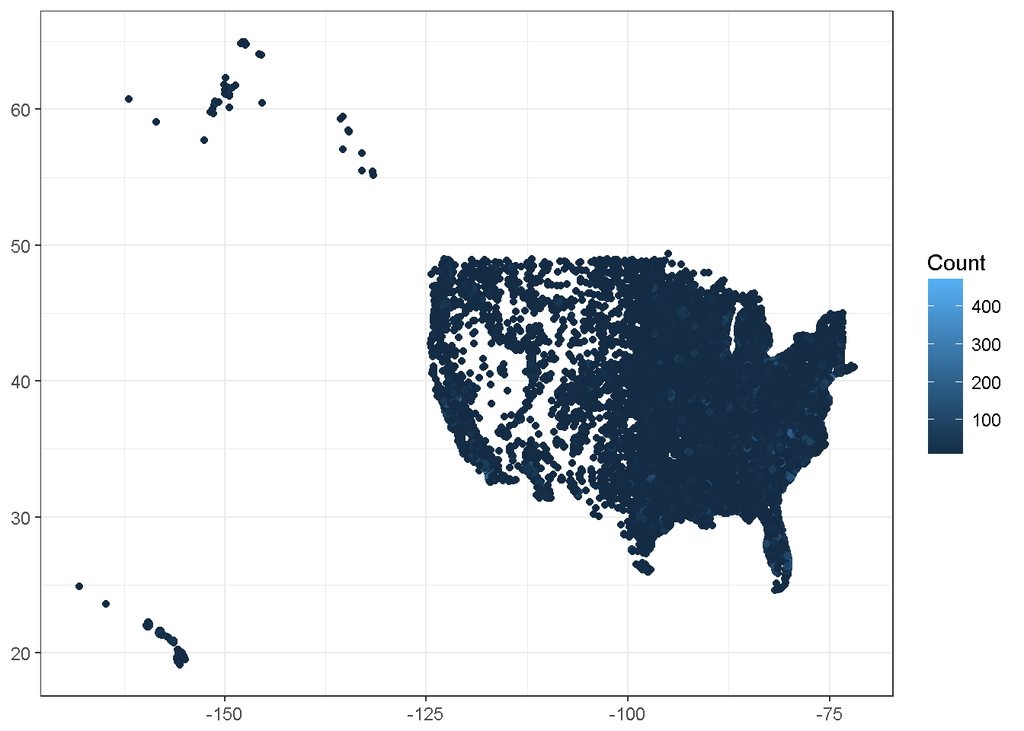

#### STATE

| Code | Count | Percent |
| --- | --- | --- |
| AK | 651 | 0.00 |
| AL | 5103 | 0.01 |
| AR | 3018 | 0.01 |
| AZ | 7333 | 0.02 |
| CA | 51862 | 0.11 |
| CO | 8156 | 0.02 |
| CT | 9038 | 0.02 |
| DE | 1398 | 0.00 |
| FL | 30426 | 0.07 |
| GA | 12981 | 0.03 |
| HI | 1804 | 0.00 |
| IA | 4936 | 0.01 |
| ID | 1430 | 0.00 |
| IL | 17570 | 0.04 |
| IN | 8420 | 0.02 |
| KS | 5063 | 0.01 |
| KY | 5961 | 0.01 |
| LA | 5460 | 0.01 |
| MA | 11757 | 0.03 |
| MD | 10516 | 0.02 |
| ME | 1406 | 0.00 |
| MI | 13307 | 0.03 |
| MN | 9738 | 0.02 |
| MO | 8576 | 0.02 |
| MS | 2296 | 0.01 |
| MT | 1150 | 0.00 |
| NC | 23174 | 0.05 |
| ND | 1161 | 0.00 |
| NE | 2994 | 0.01 |
| NH | 2261 | 0.00 |
| NJ | 18766 | 0.04 |
| NM | 1342 | 0.00 |
| NV | 2256 | 0.00 |
| NY | 24720 | 0.05 |
| OH | 17494 | 0.04 |
| OK | 2920 | 0.01 |
| OR | 4394 | 0.01 |
| PA | 21351 | 0.05 |
| RI | 1676 | 0.00 |
| SC | 9748 | 0.02 |
| SD | 1131 | 0.00 |
| TN | 8961 | 0.02 |
| TX | 32660 | 0.07 |
| UN | 1276 | 0.00 |
| UT | 2465 | 0.01 |
| VA | 14767 | 0.03 |
| VT | 800 | 0.00 |
| WA | 7935 | 0.02 |
| WI | 7276 | 0.02 |
| WV | 1307 | 0.00 |
| WY | 609 | 0.00 |

#### MARRIED

| Code | Count | Percent |
| --- | --- | --- |
| 0 | 421307 | 0.93 |
| 1 | 31493 | 0.07 |

#### INSURANCE_AGE

|  | counted | percent |
| --- | --- | --- |
| (0,20] | 1762 | 0.00 |
| (20,40] | 24076 | 0.05 |
| (40,60] | 362247 | 0.80 |
| (60,80] | 63827 | 0.14 |
| (80,100] | 639 | 0.00 |

### 4. Composite Variables

These are created by combining variable values from several of the above listed variables into a single indicator variable.

#### m50inc

Married aged 50 and older with an estimated income (ESTINC30) in F-K $50,000-$199,000.

| Code | Count | Percent |
| --- | --- | --- |
| 0 | 45295 | 0.10 |
| 1 | 333121 | 0.74 |
| 2 | 63794 | 0.14 |
| 3 | 10590 | 0.02 |

#### mf50

Married aged 50 + and female.

| Code | Count | Percent |
| --- | --- | --- |
| 0 | 44636 | 0.10 |
| 1 | 337566 | 0.75 |
| 2 | 57745 | 0.13 |
| 3 | 12853 | 0.03 |

#### m50debt

Married aged 50 plus with estimated debt between B-C, $1-$3499.

| Code | Count | Percent |
| --- | --- | --- |
| 0 | 60279 | 0.13 |
| 1 | 333093 | 0.74 |
| 2 | 52248 | 0.12 |
| 3 | 7180 | 0.02 |

#### m50inv

Married aged 50 plus with estimated invest able assets between F-J, $100,000-$1,000,000+.

| Code | Count | Percent |
| --- | --- | --- |
| 0 | 22338 | 0.05 |
| 1 | 68860 | 0.15 |
| 2 | 339877 | 0.75 |
| 3 | 21725 | 0.05 |

#### age50

Aged 50 +

| Code | Count | Percent |
| --- | --- | --- |
| 0 | 72858 | 0.16 |
| 1 | 379942 | 0.84 |

## Appendix B: Data Source Locations

- KBM:NC2PWCSQL1501/INSIGHT_RPT –last update pulled in 2016
- Policy Data:NC2DWCSQL1511/OS_Shared
- WINRISK:PGWOP

## Appendix C: Code and processing notes

-Details of performance of machine used -Scripts files and file structure